# PASS1A Rat Liver (Stanford Batch 1): What Drives Variance?

Alec Steep and Jiayu Zhang

20200325

## Goals of Analysis

- TODO: Continue Step-by-step goals of analysis
- Perform a PCA of Liver
  - If Liver clusters by sex, investigate clustering by autosomal and sex genes
    - Histogram of p values by autosomal genes and sex genes (BOTH X and Y chromosomes!)
    - Match with volcano plots
  - Either correct for sex batch, remove sex genes, or subset one sex
    - Decision: Subset by sex

## Setup the Environment

```r
################################################################################
##### Resources and Dependencies ###############################################
################################################################################

# Set the working directory
WD <- '/Volumes/Frishman_4TB/motrpac/20200309_rna-seq_steep'
#setwd(WD)

# Load the dependencies
#source("https://bioconductor.org/biocLite.R")
#BiocManager::install("caret")
#install.packages("tidyverse")

# Load dependencies
pacs...man <- c("tidyverse","GenomicRanges", "DESeq2","devtools","rafalib","GO.db","vsn","hexbin","ggplot2", "GenomicFeatures","Biostrings","BSgenome","AnnotationHub","plyr","dplyr", "org.Rn.eg.db","pheatmap","sva","formula.tools","pathview","biomaRt", "PROPER","SeqGSEA",'purrr','BioInstaller','RColorBrewer','lubridate', "hms","ggpubr", "ggrepel","genefilter","qvalue","ggfortify","som", "vsn")
lapply(pacs...man, FUN = function(X) {
        do.call("library", list(X)) })
```

[output not shown]

[output cut: 651 more lines]

```r
############################################################
##### Functions ############################################
############################################################

# Set select
select <- dplyr::select

# Make the 'not in' operator
################################################################################
'%!in%' <- function(x,y) {
        !('%in%'(x,y))
}
################################################################################

# Capture the Date and AUthor
################################################################################
date <- format.Date( Sys.Date(), '%Y%m%d' )
auth <- "steep"
################################################################################

## explicit gc, then execute `expr` `n` times w/o explicit gc, return timings
################################################################################
benchmark <- function(n = 1, expr, envir = parent.frame()) {
        expr <- substitute(expr)
        gc()
        map(seq_len(n), ~ system.time(eval(expr, envir), gcFirst = FALSE))
}
################################################################################

# Function to speed up making rows into lists for interation with lapply
################################################################################
f_pmap_aslist <- function(df) {
        purrr::pmap(as.list(df), list)
}
################################################################################
```

## Load & Clean Data

##### Data files to load:

- Count Matrix and Metadata Table from:
  - RNA-Seq from Mt. Sinai
    - 3 sequencing batches & metadata
  - RNA-Seq from Stanford
    - 2 sequencing batches & metadata

```r
################################################################################
#####     Load & Clean Data      ###############################################
################################################################################

# Files last saved in: 20200309_exploration-rna-seq-phase1_steep.R

# Count matrix
in_file <- paste0(WD,'/data/20200309_rnaseq-countmatrix-pass1a-stanford-sinai_steep.csv')
count_data <- read.table(in_file,sep = ',', header = TRUE,row.names = 1,check.names = FALSE)

# Meatdata table
in_file <- paste0(WD,'/data/20200309_rnaseq-meta-pass1a-stanford-sinai_steep.txt')
col_data <- read.table(in_file, header = TRUE, check.names = FALSE, sep = '\t')
row.names(col_data) <- col_data$sample_key

# Adjust columns
col_data$animal.key.exlt4 <- as.factor(col_data$animal.key.exlt4)
```

## Place Genes in Genomic Ranges

#### Reference Genome and Annotation: Rnor_6.0 (GCA_000001895.4) assembly from Ensembl database (Release 96)

Found at: http://uswest.ensembl.org/Rattus_norvegicus/Info/Index.

FASTA: Rattus_norvegicus.Rnor_6.0.dna.toplevel.fa.gz ftp://ftp.ensembl.org/pub/release-96/fasta/rattus_norvegicus/dna/Rattus_norvegicus.Rnor_6.0.dna.toplevel.fa.gz

GTF: Rattus_norvegicus.Rnor_6.0.96.gtf.gz ftp://ftp.ensembl.org/pub/release-96/gtf/rattus_norvegicus/Rattus_norvegicus.Rnor_6.0.96.gtf.gz

```r
################################################################################
#####     Annotate Genes by Chromosome       ###################################
################################################################################

### Determine which control samples are male and female
# Get the list of genes on the W chromosome

# Construct your own personal galgal5 reference genome annotation
# Construct from gtf file from Ensembl (same file used in mapping)
ens_gtf <- paste0(WD,'/data/Rattus_norvegicus.Rnor_6.0.96.gtf')
Rn_TxDb <- makeTxDbFromGFF(ens_gtf,
                           format=c("gtf"),
                           dataSource="Ensembl_Rattus6_gtf",
                           organism="Rattus norvegicus",
                           taxonomyId=NA,
                           circ_seqs=DEFAULT_CIRC_SEQS,
                           chrominfo=NULL,
                           miRBaseBuild=NA,
                           metadata=NULL)

# Define Female specific sex genes (X chromosome)
# To examine chromosome names
seqlevels(Rn_TxDb)[1:23]
```

```
##  [1] "1"  "2"  "3"  "4"  "5"  "6"  "7"  "8"  "9"  "10" "11" "12" "13" "14" "15"
## [16] "16" "17" "18" "19" "20" "X"  "Y"  "MT"
```

```r
# Extract genes as GRanges object, then names
X_genes_gr <- genes(Rn_TxDb, columns = "TXCHROM", filter = list(tx_chrom=c("X")))
# Collect ensembl gene ids for female specific genes
X_ens_id <- names(X_genes_gr)
# Examine the gene symbols
X_sym <- mapIds(org.Rn.eg.db, names(X_genes_gr), "SYMBOL", "ENSEMBL")
# Extract genes as GRanges object, then names
Y_genes_gr <- genes(Rn_TxDb, columns = "TXCHROM", filter = list(tx_chrom=c("Y")))
# Collect ensembl gene ids for female specific genes
Y_ens_id <- names(Y_genes_gr)
sex_ens_id <- c(X_ens_id,Y_ens_id)
# Examine the gene symbols
Y_sym <- mapIds(org.Rn.eg.db, names(Y_genes_gr), "SYMBOL", "ENSEMBL")
```

## Normalization for Sequencing Depth

```r
################################################################################
#####     Normalization for Sequencing Depth      ##############################
################################################################################
```

##### Liver Samples (80 unique) from 1 batch were filtered prior to normalization

One outlier removed: TODO: Document removal of outlier in seperate script

```r
livers <- col_data %>%
  filter(Tissue == 'Liver') %>%
  filter(sample_key != '90042016803_SF1') %>%
  select(sample_key) %>% unlist() %>% as.character()
liver_counts <- count_data[,livers] %>% as.matrix()

# All samples unique?
#col_data %>%
#  filter(Tissue == 'Liver') %>%
#  select(vial_label) %>% unlist() %>% unique() %>% length()

# SUbset liver metadata
liver_cols <- col_data %>%
  filter(Tissue == 'Liver') %>%
  filter(sample_key != '90042016803_SF1')
row.names(liver_cols) <- liver_cols$sample_key
```

#### Sanity Check: Ensure that the metadata rownames are identical to count matrix column names

```r
all(rownames(liver_cols) == colnames(liver_counts))
```

```
## [1] TRUE
```

```r
design = ~ 1 # Primary variable needs to be last
title = paste0('Design: ',as.character(design))
# Create a DESeqDataSet Object
dds <- DESeqDataSetFromMatrix(countData = liver_counts,
                              colData = liver_cols,
                              design = design)

# Perform pre-filtering.
# Filter genes with average count of 10 or less.
# Reasoning from:
#citation("PROPER")
#dds
```

Before Filtering

```r
dds
```

```
## class: DESeqDataSet
## dim: 32883 79
## metadata(1): version
## assays(1): counts
## rownames(32883): ENSRNOG00000055633 ENSRNOG00000058846 ...
##   ENSRNOG00000055837 ENSRNOG00000055723
## rowData names(0):
## colnames(79): 90155016803_SF1 90037016803_SF1 ... 90001016803_SF1
##   90135016803_SF1
## colData names(204): vial_label X2D_barcode ...
##   specimen.collection.t_death_bins
##   specimen.collection.t_death_bins.type
```

```r
keep <- rowSums(counts(dds))/ncol(dds) > 3
dds <- dds[keep,]
```

#### Summary of counts and annotation data in a DESeqDataSet after filtering out genes with low sequencing depth

```r
dds
```

```
## class: DESeqDataSet
## dim: 15046 79
## metadata(1): version
## assays(1): counts
## rownames(15046): ENSRNOG00000058846 ENSRNOG00000054582 ...
##   ENSRNOG00000056235 ENSRNOG00000058021
## rowData names(0):
## colnames(79): 90155016803_SF1 90037016803_SF1 ... 90001016803_SF1
##   90135016803_SF1
## colData names(204): vial_label X2D_barcode ...
##   specimen.collection.t_death_bins
##   specimen.collection.t_death_bins.type
```

```r
mypar()
```

#### When we plot counts for genes across 2 samples, we see that genes with high counts will demonstrate high variance in non-normalized non-transformed data.

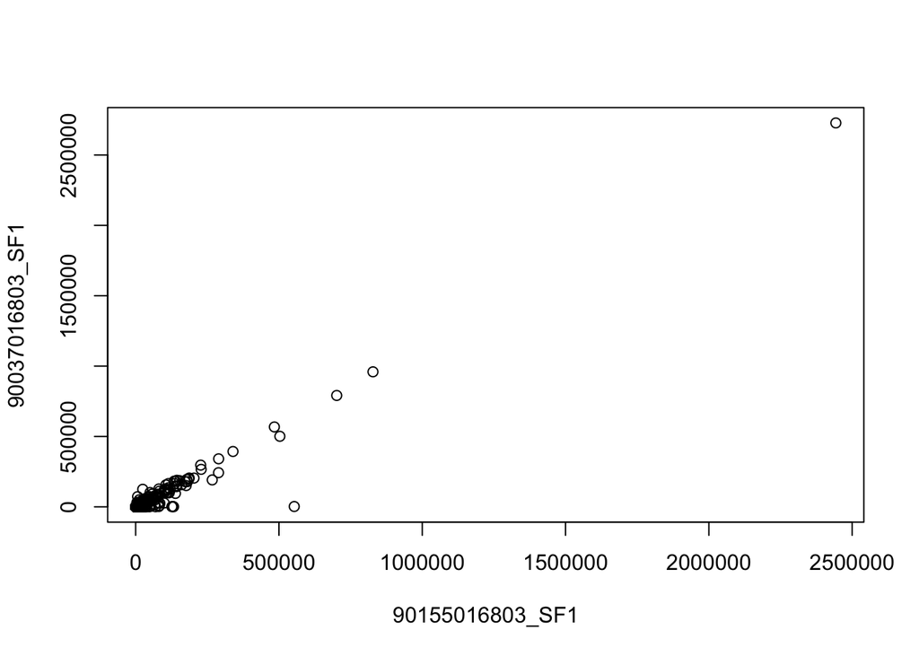

```r
plot(assay(dds)[,1:2], cex=1)
```

To see the reads per million for each sample

```r
sort(colSums(assay(dds)))/1e6
```

```
## 90018016803_SF1 90123016803_SF1 90045016803_SF1 90031016803_SF1 90014016803_SF1
##        20.32439        20.88264        21.60653        22.00754        22.25697
## 90009016803_SF1 90112016803_SF1 90028016803_SF1 90135016803_SF1 90007016803_SF1
##        22.41842        22.83497        22.93139        23.11795        23.26153
## 90033016803_SF1 90039016803_SF1 90046016803_SF1 90143016803_SF1 80003996821_SF1
##        23.37354        23.52746        23.72225        23.87794        23.91411
## 90029016803_SF1 90156016803_SF1 90038016803_SF1 90041016803_SF1 90048016803_SF1
##        24.20298        24.21012        24.56001        24.61670        24.64537
## 90150016803_SF1 90138016803_SF1 90134016803_SF1 90023016803_SF1 90117016803_SF1
##        24.66026        25.09262        25.27156        25.27333        25.38109
## 90017016803_SF1 90050016803_SF1 90136016803_SF1 90124016803_SF1 90144016803_SF1
##        25.38421        25.43136        25.44024        25.53987        25.59020
## 90005016803_SF1 90053016803_SF1 90027016803_SF1 90122016803_SF1 90148016803_SF1
##        25.62757        25.67267        25.84918        25.90766        25.91521
## 90140016803_SF1 90121016803_SF1 90044016803_SF1 90142016803_SF1 90015016803_SF1
##        26.07447        26.11950        26.57476        26.66457        26.76662
## 90126016803_SF1 90114016803_SF1 90128016803_SF1 90145016803_SF1 90047016803_SF1
##        26.80964        26.83519        26.92327        27.07531        27.17300
## 90146016803_SF1 90011016803_SF1 90115016803_SF1 90109016803_SF1 80002886821_SF1
##        27.36098        27.48719        27.58029        27.62599        27.76971
## 90001016803_SF1 90008016803_SF1 90129016803_SF1 90159016803_SF1 90119016803_SF1
##        27.79066        27.92083        28.04110        28.13133        28.17287
## 90141016803_SF1 90025016803_SF1 90155016803_SF1 90026016803_SF1 90110016803_SF1
##        28.24008        28.32582        28.78927        29.26052        29.26818
## 90133016803_SF1 90157016803_SF1 90152016803_SF1 90012016803_SF1 90043016803_SF1
##        30.04171        30.06702        30.08096        30.16373        30.20949
## 90013016803_SF1 90037016803_SF1 90034016803_SF1 90040016803_SF1 90120016803_SF1
##        30.35359        30.60823        30.85791        31.20030        32.36364
## 90032016803_SF1 90160016803_SF1 90139016803_SF1 90118016803_SF1 90020016803_SF1
##        33.02869        34.17993        34.31891        35.13771        37.68585
## 90010016803_SF1 90147016803_SF1 90127016803_SF1 90052016803_SF1
##        38.42103        38.70973        39.53451        42.29003
```

```r
summary(colSums(assay(dds))/1e6)
```

```
##    Min. 1st Qu.  Median    Mean 3rd Qu.    Max.
##   20.32   24.65   26.77   27.50   29.26   42.29
```

```r
# estimateSizeFactors gives us a robust estimate in sequencing depth
dds <- estimateSizeFactors(dds)
```

#### If we plot the total counts for each sample (colSums) vs each sample size factors, we see they are strongly correlated–size factors act as a coefficient for sequencing depth

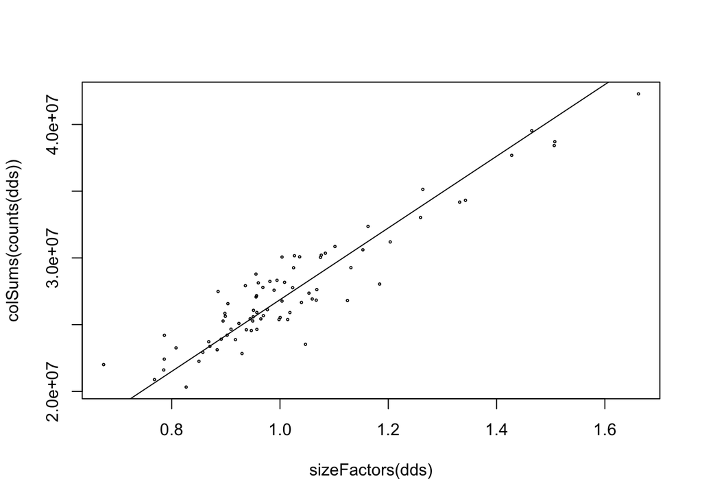

```r
plot(sizeFactors(dds), colSums(counts(dds)), cex=.3)
abline(lm(colSums(counts(dds)) ~ sizeFactors(dds) + 0))
```

Size facotrs are generally around 1 (scaled) and calculated using the median and are robust to genes with large read counts

```r
sort(sizeFactors(dds))
```

```
## 90031016803_SF1 90123016803_SF1 90045016803_SF1 90009016803_SF1 90029016803_SF1
##       0.6742952       0.7682181       0.7852768       0.7862976       0.7864991
## 90007016803_SF1 90018016803_SF1 90014016803_SF1 90028016803_SF1 90046016803_SF1
##       0.8080259       0.8267095       0.8503051       0.8575143       0.8683832
## 90033016803_SF1 90135016803_SF1 90011016803_SF1 80003996821_SF1 90134016803_SF1
##       0.8705233       0.8839467       0.8856711       0.8914751       0.8948901
## 90027016803_SF1 90005016803_SF1 90156016803_SF1 90044016803_SF1 90150016803_SF1
##       0.8982253       0.8990248       0.9023583       0.9037896       0.9095465
## 90143016803_SF1 90138016803_SF1 90112016803_SF1 90008016803_SF1 90041016803_SF1
##       0.9177129       0.9241083       0.9298435       0.9360490       0.9378311
## 90136016803_SF1 90038016803_SF1 90023016803_SF1 90144016803_SF1 90140016803_SF1
##       0.9449232       0.9470476       0.9496487       0.9505451       0.9510824
## 90155016803_SF1 90145016803_SF1 90047016803_SF1 90148016803_SF1 90048016803_SF1
##       0.9556493       0.9558272       0.9566383       0.9571871       0.9572628
## 90159016803_SF1 90050016803_SF1 90001016803_SF1 90053016803_SF1 90121016803_SF1
##       0.9599690       0.9646522       0.9684241       0.9692912       0.9767144
## 90141016803_SF1 90115016803_SF1 90025016803_SF1 90117016803_SF1 90124016803_SF1
##       0.9813223       0.9890562       0.9944823       0.9982090       1.0003099
## 90015016803_SF1 90157016803_SF1 90119016803_SF1 90017016803_SF1 90122016803_SF1
##       1.0037028       1.0037451       1.0084459       1.0141908       1.0183061
## 80002886821_SF1 90026016803_SF1 90012016803_SF1 90152016803_SF1 90142016803_SF1
##       1.0234130       1.0250862       1.0266849       1.0362800       1.0396341
## 90039016803_SF1 90146016803_SF1 90128016803_SF1 90114016803_SF1 90109016803_SF1
##       1.0470470       1.0534737       1.0594950       1.0669219       1.0679658
## 90133016803_SF1 90043016803_SF1 90013016803_SF1 90034016803_SF1 90126016803_SF1
##       1.0747691       1.0761974       1.0837526       1.1015109       1.1245817
## 90110016803_SF1 90037016803_SF1 90120016803_SF1 90129016803_SF1 90040016803_SF1
##       1.1309466       1.1530780       1.1625600       1.1839965       1.2035281
## 90032016803_SF1 90118016803_SF1 90160016803_SF1 90139016803_SF1 90020016803_SF1
##       1.2595390       1.2637537       1.3318359       1.3425050       1.4278885
## 90127016803_SF1 90010016803_SF1 90147016803_SF1 90052016803_SF1
##       1.4649741       1.5064573       1.5075170       1.6620289
```

```r
summary(sizeFactors(dds))
```

```
##    Min. 1st Qu.  Median    Mean 3rd Qu.    Max.
##  0.6743  0.9136  0.9767  1.0187  1.0674  1.6620
```

How size factor is computed for a sample: Size factors are from the median ratio of samples compared to a pseudo-sample, which is the geometric mean of all samples.

```r
loggeomeans <- rowMeans(log(counts(dds)))
exp(median((log(counts(dds)[,1]) - loggeomeans)[is.finite(loggeomeans)])) == sizeFactors(dds)[1]
```

```
## 90155016803_SF1
##            TRUE
```

### Comparison of transformation techniques

```r
################################################################################
#####     Transformation Techniques      #######################################
################################################################################
```

##### Log2 normalization (with size factor and pseudo count)

```r
log_norm_counts <- log2(counts(dds, normalized=TRUE) + 1)
```

##### Variance stabilizing transformation (VST) uses a subset of genes and divides each column of the counts matrix by our size factors. It also normalizes with respect to library size.

```r
vstd <- vst(dds)
```

Regularized Log (rlog) The purpose of using the “regularized log” transformation is to shrink together the values of the genes that have very low counts (“shrinkage” technique in statistics). Rlog is close to log2 transform.

```r
#Time difference of 2.914409 mins (on Macbook pro)
for( n in 1){
  start_time <- Sys.time()
  rld <- rlog(dds)
  end_time <- Sys.time()
  print(end_time - start_time)
}
```

```
## Time difference of 3.88508 mins
```

```r
# This command is redundent, but included for safety
rs <- rowSums(counts(dds))
```

#### Here we visualize the counts from log2 transformation and from the rlog transform

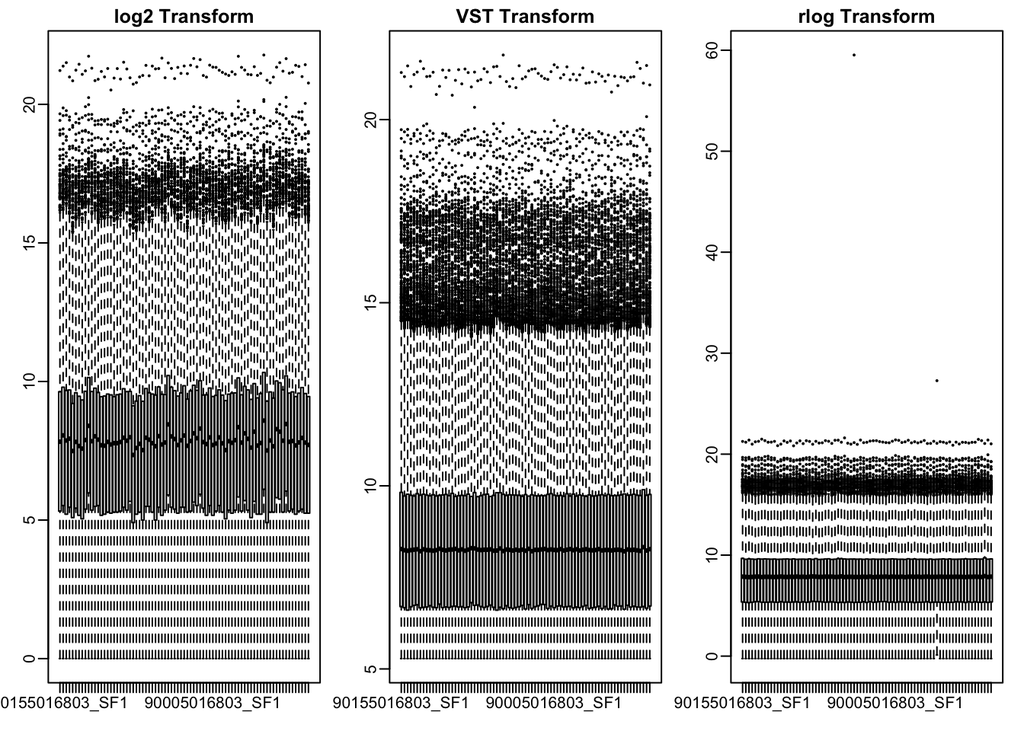

```r
mypar(1,3)
boxplot(log2(counts(dds)[rs > 0,] +1), cex=0.2, main = "log2 Transform") # Log2 Transform
boxplot(assay(vstd)[rs > 0,], cex=0.2, main = "VST Transform") # VST Transform
boxplot(assay(rld)[rs > 0,], cex=0.2, main = "rlog Transform") # Regularized Log Transform
```

##### Returning to our prior plot of comparing expression of 2 samples, we can see the the variance is now more stable in VST and rlog transforms. However, the VST transform demonstrates a lot of variance in genes with low read counts. For that reason, we will proceed with rlog transform.

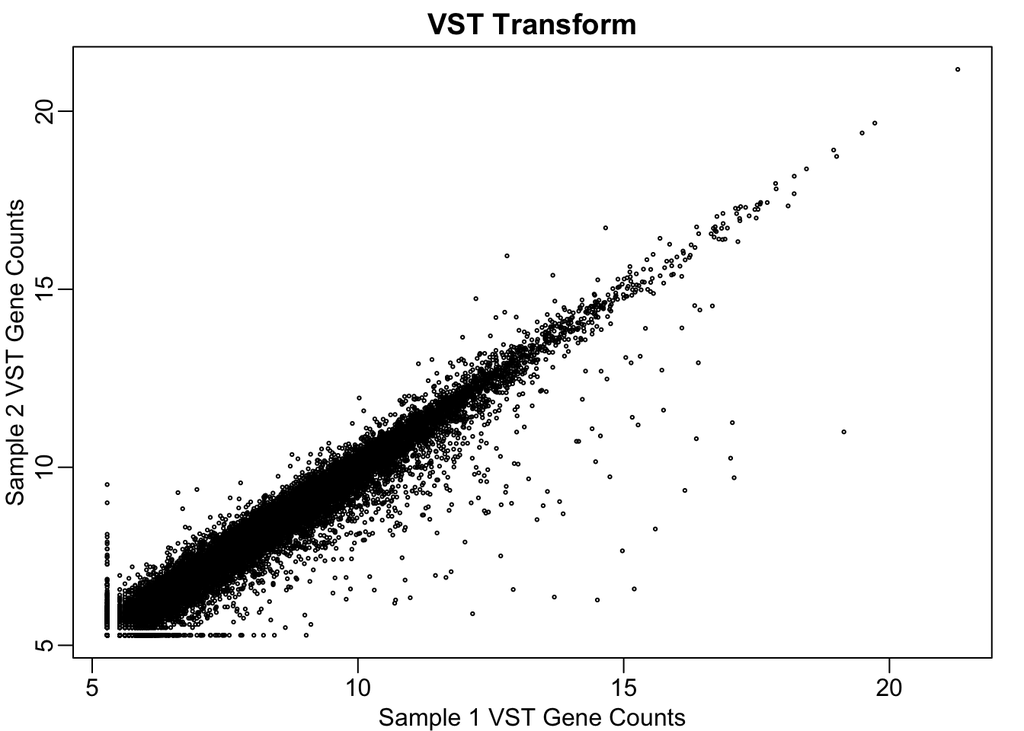

```r
mypar(1,1)
plot(assay(vstd)[,c(1,2)],
     xlab = "Sample 1 VST Gene Counts",
     ylab = "Sample 2 VST Gene Counts",
     cex = 0.3, main = "VST Transform" )
```

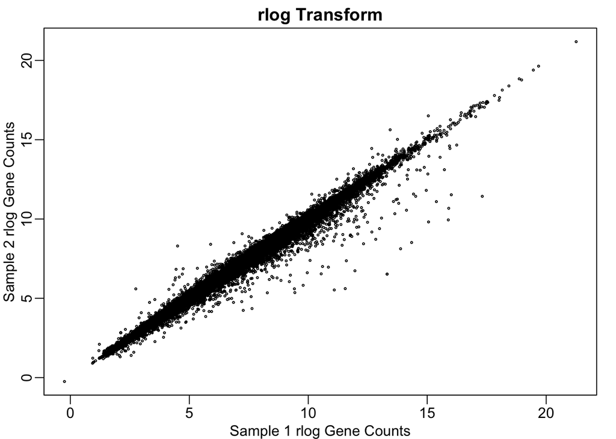

```r
plot(assay(rld)[,c(1,2)],
     xlab = "Sample 1 rlog Gene Counts",
     ylab = "Sample 2 rlog Gene Counts",
     cex = 0.3, main = "rlog Transform")
```

##### Another plot to examine the difference between transformations is a mean standard deviation plot, which calculates–for each gene–the mean over all samples and the standard deviation over all samples. rlog and vst transforms are comparable.

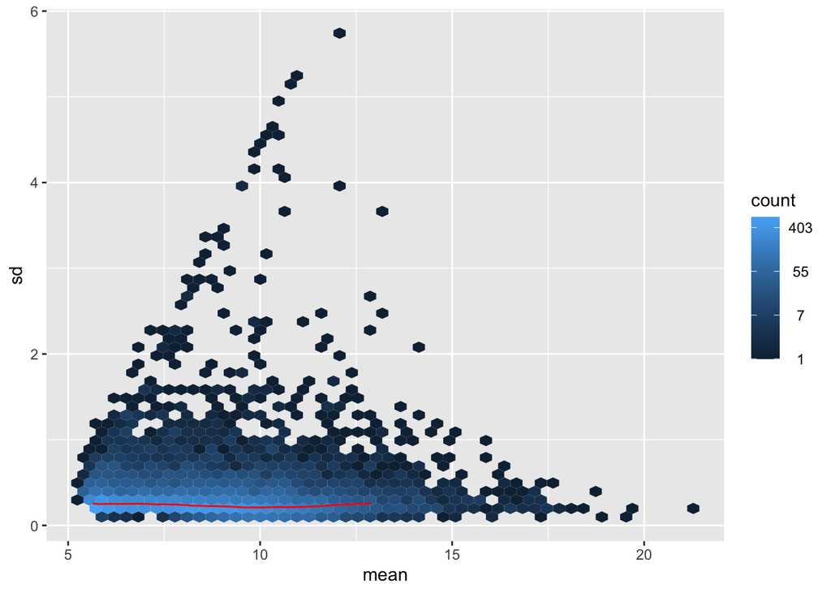

```r
mypar(1,2)
#meanSdPlot(log_norm_counts, ranks=FALSE)
mds_vst <- meanSdPlot(assay(vstd)[rs > 0,], ranks=FALSE)
```

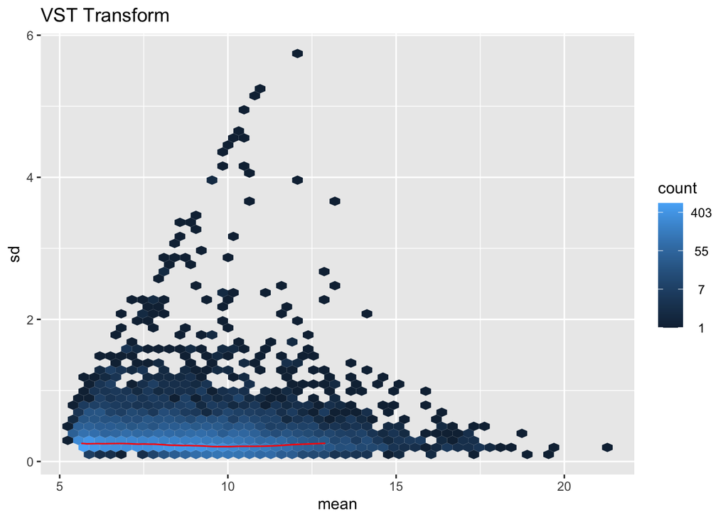

```r
mds_vst$gg + ggtitle("VST Transform")
```

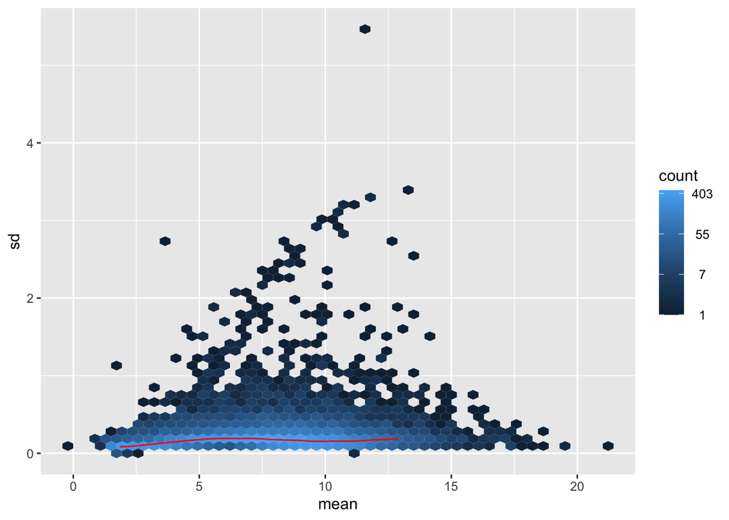

```r
mds_rlog <- meanSdPlot(assay(rld)[rs > 0,], ranks=FALSE)
```

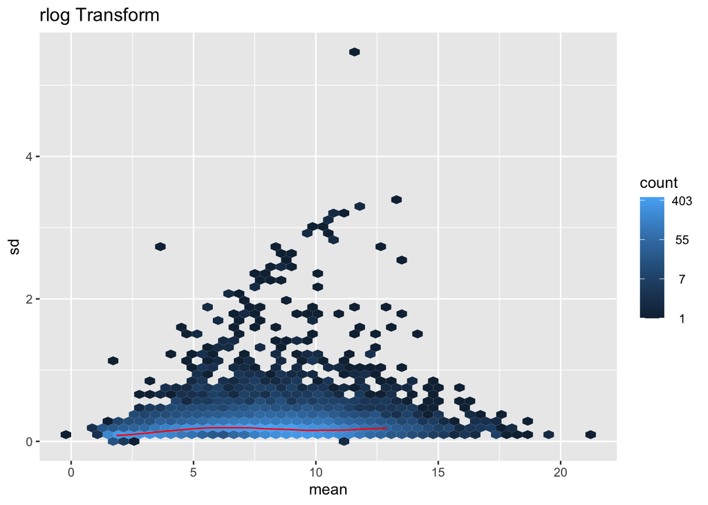

```r
mds_rlog$gg + ggtitle("rlog Transform")
```

```r
################################################################################
```

## PCA of Liver Samples

Samples from Stanford Batch 1, which we suspect demonstrates a strong technical batch effect

```r
################################################################################
#####     PCA of Liver Samples       ###########################################
################################################################################

# Extract matrix of normalized counts
#rld_backup <- rld
#rld <- vstd
norm_counts <- assay(rld)
counts <- as.data.frame(norm_counts)

# Annotate normalized counts
counts$ensembl <- rownames(counts)
counts$symbol <- mapIds(org.Rn.eg.db, counts$ensembl, "SYMBOL", "ENSEMBL")
counts$entrez <- mapIds(org.Rn.eg.db, counts$ensembl, "ENTREZID", "ENSEMBL")
counts$genename <- mapIds(org.Rn.eg.db, counts$ensembl, "GENENAME", "ENSEMBL")
counts$go <- mapIds(org.Rn.eg.db, counts$ensembl, "GO", "ENSEMBL")
counts$path <- mapIds(org.Rn.eg.db, counts$ensembl, "PATH", "ENSEMBL")
```

#### Liver samples cluster by sex.

Grey samples represent “reference samples”.

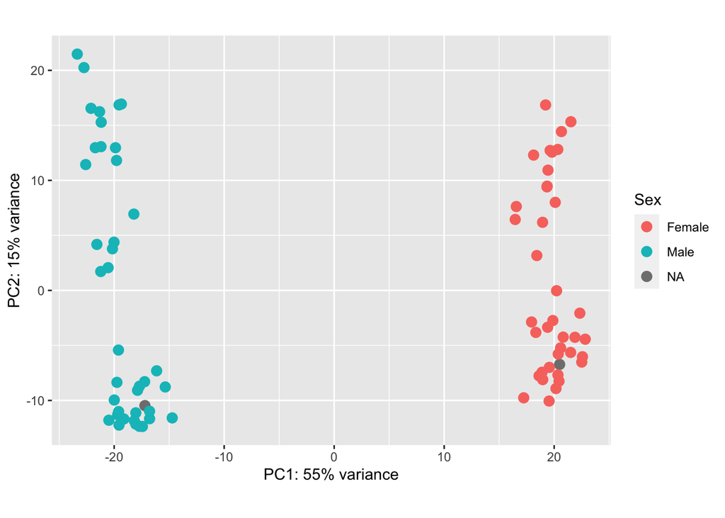

```r
DESeq2::plotPCA(rld, intgroup ="animal.registration.sex") +
        guides(color=guide_legend(title="Sex"))
```

```r
# Variables of interest
male_livers <- (liver_cols %>%
                        filter(animal.registration.sex == 'Male'))$sample_key %>%
        as.character()
female_livers <- (liver_cols %>%
                          filter(animal.registration.sex == 'Female'))$sample_key %>%
        as.character()
ref_livers <- (liver_cols %>%
                       filter(is.na(animal.registration.sex)))$sample_key %>%
        as.character()
livers <- c(male_livers,female_livers,ref_livers)
Y_genes <- Y_ens_id[Y_ens_id %in% row.names(norm_counts)]
X_genes <- X_ens_id[X_ens_id %in% row.names(norm_counts)]
sex <- liver_cols[livers,"animal.registration.sex"]
group <- liver_cols[livers,"animal.key.anirandgroup"]
```

```r
chryexp <- colMeans(norm_counts[Y_genes,])
#chryexp <- colMeans(assay(dds)[Y_genes,])

chryexp_df <- data.frame("counts" = chryexp)
chryexp_df$sample <- row.names(chryexp_df) %>% as.factor()
chryexp_df <- chryexp_df %>%
  mutate(sex = ifelse(sample %in% male_livers, 'Male', 'Female'))
```

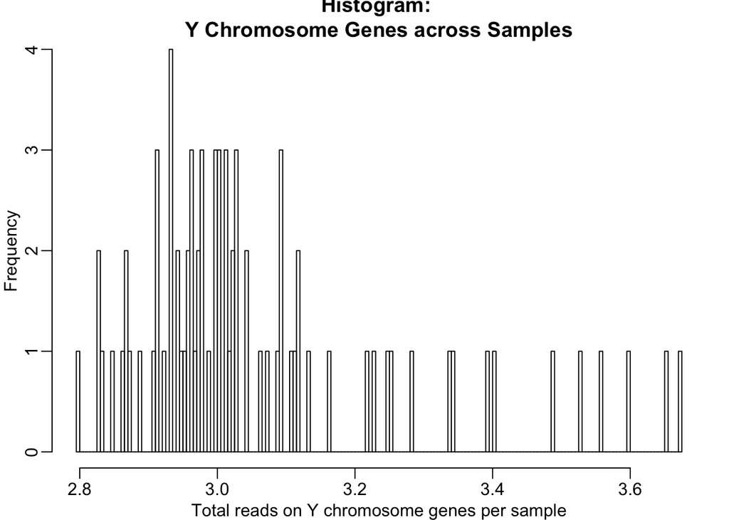

```r
mypar()
hist(chryexp_df$counts, breaks = 200,
     main = "Histogram: \nY Chromosome Genes across Samples",
     xlab = "Total reads on Y chromosome genes per sample")
```

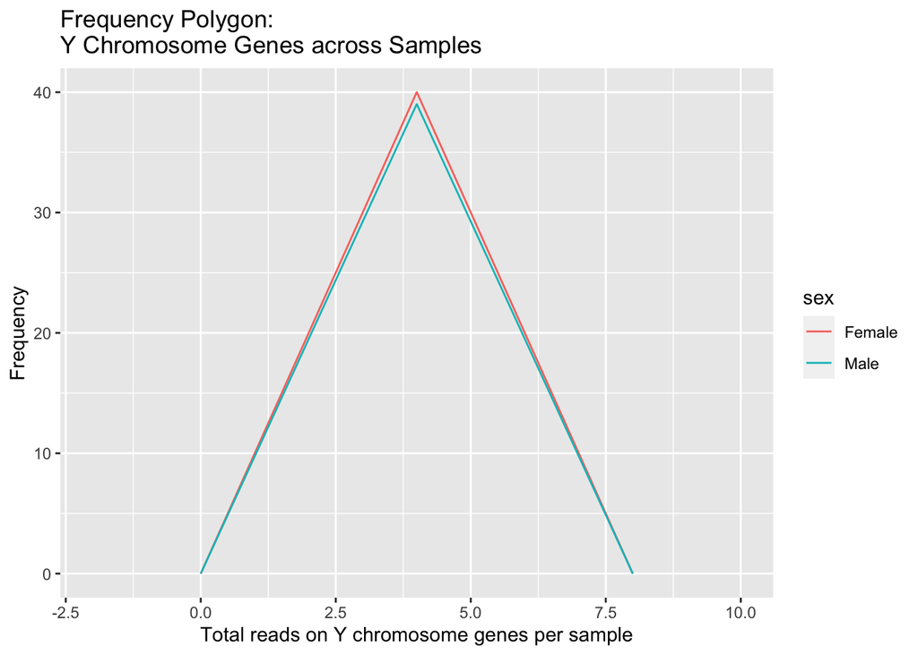

```r
ggplot(chryexp_df, aes(counts, colour = sex)) +
  geom_freqpoly(binwidth = 4) +
  xlab("Total reads on Y chromosome genes per sample") +
  ylab("Frequency") +
  ggtitle("Frequency Polygon: \nY Chromosome Genes across Samples")
```

```r
# summary(chryexp)
```

We will not use this common strategy to determine sex of unknown samples, rather we will use clustering from PCA. The distribution of sex by group

```r
table(group, sex) # <- Bad idea.
```

```
##                    sex
## group               Female Male
##   Control - 7 hr         5    5
##   Control - IPE          5    5
##   Exercise - 0.5 hr      5    5
##   Exercise - 1 hr        5    5
##   Exercise - 24 hr       3    3
##   Exercise - 4 hr        5    5
##   Exercise - 48 hr       2    3
##   Exercise - 7 hr        3    3
##   Exercise - IPE         5    5
```

#### Generate a heatmap of expression from 3 sets of genes:

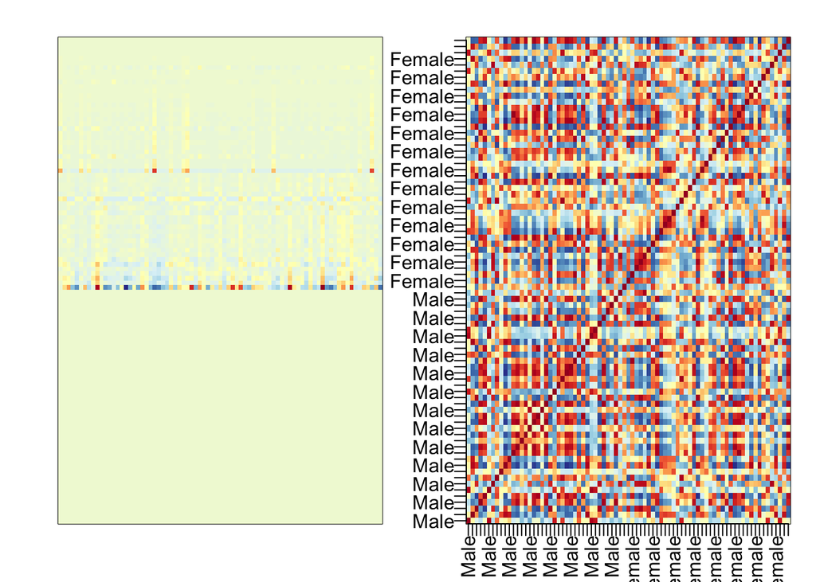

```r
# T-test of expression associated with sex
tt <- rowttests(liver_counts,sex)

# Take genes from the Y chromosome
# Y_genes
# Take the top and bottom 25 genes associated with variable of interest (remove any genes in Y chromosome)
top <- row.names(tt[order(-tt$dm),][1:25,])
bot <- row.names(tt[order(tt$dm),][1:25,])
top_n_bot <- setdiff(c(top,bot), Y_genes)

# Randomly select 50 genes not in prior sets
set.seed(123)
randos <- setdiff(row.names(tt[sample(seq(along=tt$dm),50),]), c(Y_genes,top_n_bot))
geneindex <- c(randos,top_n_bot,Y_genes)
# Generate the heatmap and support with a plot of a correlation matrix
mat <- liver_counts[geneindex,]
mat <- mat -rowMeans(mat)
icolors <- colorRampPalette(rev(brewer.pal(11,"RdYlBu")))(100)
mypar(1,2)
image(t(mat),xaxt="n",yaxt="n",col=icolors)
y <- liver_counts - rowMeans(liver_counts)
image(1:ncol(y),1:ncol(y),cor(y),col=icolors,zlim=c(-1,1),
      xaxt="n",xlab="",yaxt="n",ylab="")
axis(2,1:ncol(y),sex,las=2)
axis(1,1:ncol(y),sex,las=2)
```

## The variance in gene expression is not dicated by differential expression of genes on sex chromosomes.

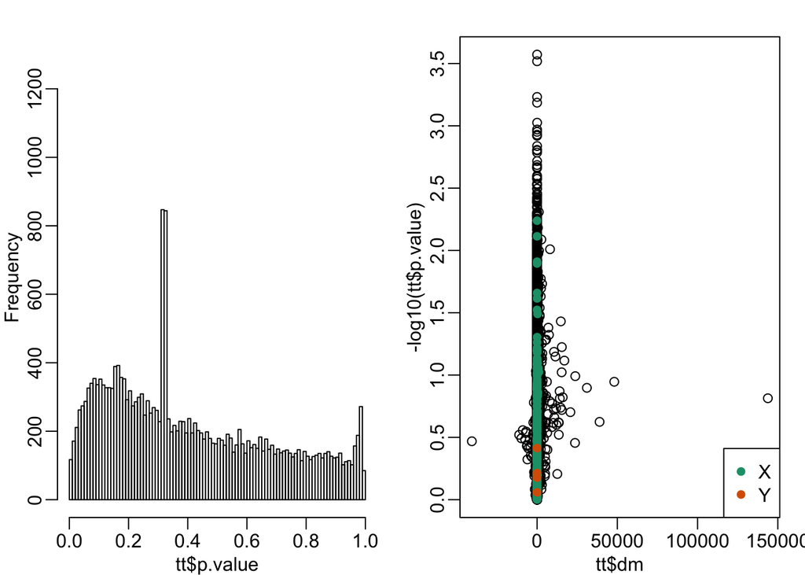

```r
mypar(1,2)
# Histogram of p values associated with ttest
hist(tt$p.value,main="",ylim=c(0,1300), breaks = 100)
plot(tt$dm,-log10(tt$p.value))
points(tt[X_genes,]$dm,-log10(tt[X_genes,]$p.value),col=1,pch=16)
points(tt[Y_genes,]$dm,-log10(tt[Y_genes,]$p.value),col=2,pch=16, xlab="Effect size",ylab="-log10(p-value)")
legend("bottomright",c("X","Y"),col=1:2,pch=16)
p <- tt$p.value
qvals <- qvalue(tt$p.value)$qvalue
index <- which(qvals<=0.05)
abline(h=-log10(max(tt$p.value[index])))
```

#### End of Script Notes

```r
################################################################################
################ End of Script Notes ###########################################
################################################################################

# TODO: Something is funky in this script
# TODO: Go find kidney script and sort out the ordering of samples
```